# Empirical Finance: Tutorial - Week 2

Tomás Cordeiro da Silva

2024-01-15

# Setup

## Working Directory

```r
# --- confirm working directory
getwd()
```

```
## [1] "C:/Users/tsilva/OneDrive - Imperial College London/Desktop/TA/EF/Tutorials/Week 2/PS2_Solutions"
```

```r
# --- list existing files
list.files()
```

```
## [1] "tutorial_week2.html"  "tutorial_week2.Rmd"   "tutorial_week2_files"
```

## Housekeeping

```r
# --- removes all objects from the the current environment
rm(list = ls())
```

## Packages

```r
# --- defining the packages required
packages <- c(
  "quantmod",   # download time-series
  "tidyverse",  # data manipulation and visualization
  "stargazer",  # publication-ready tables
  "conflicted", # management of function name conflicts across packages
  "moments",    # statistical moments, like skewness and kurtosis
  "lubridate",  # manipulation of data
  "knitr",      # integrate R code with text (e.g. LaTeX, HTML, Markdown)
  "sn",         # simulation of skewed distributions
  "patchwork"   # composition of graphs
)

# --- from the ones needed extract the ones not installed
to_install <- packages[!packages %in% installed.packages()[, "Package"]]

# --- install the packages
if (length(to_install) > 0) {
  install.packages(to_install)
}

# --- load the packages in our session
invisible(lapply(packages, library, character.only = TRUE))

# --- defining `lag()` from the dplyr package as the preference
conflict_prefer("lag", "dplyr")
```

# Data

To download our data we will be using the `quantmod` package. This package connects us to our sources, using their public API’s. The data extracted will be converted to an `xts` object.

- What is an `xts` object? I s a class of objects in R for time series, where indices are dates.

A brief reference to `getSymbols` syntax:

- `Symbols`: requires the ticker (i.e. standardized identifier) of our variable
- `src`: requires de source (i.e. where to read the ticker/which API to connect)

## S&P500 Index

```r
getSymbols(Symbols = "^GSPC", src = "yahoo")
```

```
## [1] "GSPC"
```

```r
sp500 <- data.frame(
  # -- extracts the index, which in xts objects is the date
  date  = index(GSPC),
  # -- extracts "GSPC.Adjusted"; alternative: GSPC[, "GSPC.Adjusted"]
  SP500 = as.numeric(Ad(GSPC))
)
```

## GBPUSD Exchange Rate

```r
getSymbols(Symbols = "GBPUSD=X", src = "yahoo")
```

```
## [1] "GBPUSD=X"
```

```r
gbpusd <- data.frame(
  date  = index(`GBPUSD=X`),
  GBPUSD = as.numeric(Ad(`GBPUSD=X`))
)
```

## US Federal Fund Rate

```r
getSymbols(Symbols = "DFF", src = "FRED")
```

```
## [1] "DFF"
```

```r
usffr <- data.frame(
  date  = index(DFF),
  EFF = as.numeric(DFF)
)
```

# Exercise 1

Let’s start of by computing daily simple and log return.

The *one-period* **net simple return** between time $t$ and $t + 1$ is given by:

$$R_{t+1} - 1 = \frac{P_{t+1}}{P_{t}} -1 \Leftrightarrow R_{t} - 1 =
\frac{P_{t}}{P_{t-1}} -1$$

The *one-period* **log return** between time $t$ and $t + 1$ is given by:

$$r_{t+1} = ln(R_{t+1}) = ln\left(\frac{P_{t+1}}{P_{t}}\right) =
ln(P_{t+1}) - ln(P_{t})$$

```r
# --- S&P500 Index
sp500_d <- sp500 %>%
  mutate(
    dr = (SP500 / lag(SP500))-1,
    lr = log(SP500) - log(lag(SP500))
  )

# --- GBPUSD Exchange Rate
gbpusd_d <- gbpusd %>%
  mutate(
    dr = (GBPUSD / lag(GBPUSD))-1,
    lr = log(GBPUSD) - log(lag(GBPUSD))
  )

# --- US Federal Fund Rate
usffr_d <- usffr %>%
  mutate(
    dr = (EFF / lag(EFF))-1,
    lr = log(EFF) - log(lag(EFF))
  )
```

```r
# --- alternative using `quantmod`
sp500_xts <- getSymbols("^GSPC", src = "yahoo", auto.assign = FALSE)

sp500_dr <- dailyReturn(Ad(sp500_xts), type = "arithmetic")
sp500_lr <- dailyReturn(Ad(sp500_xts), type = "log")
```

```r
# --- storing all these individual datasets in a single list
data_list <- list(
  SP500 = sp500_d,
  GBPUSD = gbpusd_d,
  EFF = usffr_d
  )
```

It may be tempting to merge all series and compute simple and log returns in a single operation. However, this approach overlooks a critical data-integrity issue: not all time series are observed continuously over time.

Both the S&P 500 Index and the GBP/USD exchange rate exhibit systematic breaks over weekends, whereas the US Federal Funds Rate is recorded for all calendar dates. Moreover, the Federal Funds Rate begins earlier in the sample, which would naturally lead to a `left_join` of the other two series onto it.

This operation introduces missing values on non-trading days. As a consequence, return calculations become distorted: a Monday observation is no longer compared to the preceding Friday, but instead to an `NA`, breaking the economic interpretation of returns and compromising downstream analysis.

```r
lapply(data_list, function(df) {
  any(diff(df$date) > 1)
})
```

```
## $SP500
## [1] TRUE
##
## $GBPUSD
## [1] TRUE
##
## $EFF
## [1] FALSE
```

```r
# --- building this joined dataset to visualize our argument
# test <- usffr %>%
#   left_join(sp500, by = "date") %>%
#   left_join(gbpusd, by = "date") %>%
#   arrange(date) %>%
#   mutate(
#     across(
#       .cols = where(is.numeric) ,
#       .fns  = list(
#         sr = ~ .x / lag(.x) -1,
#         lr = ~ log(.x) - log(lag(.x))
#       ) ,
#       .names = "{.fn}_{.col}"
#     )
#   )
```

## a)

Plot simple returns.

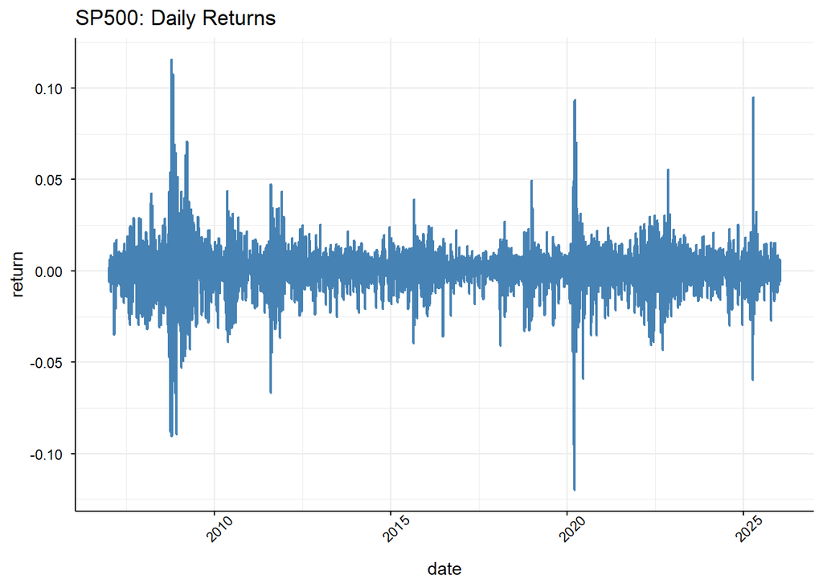

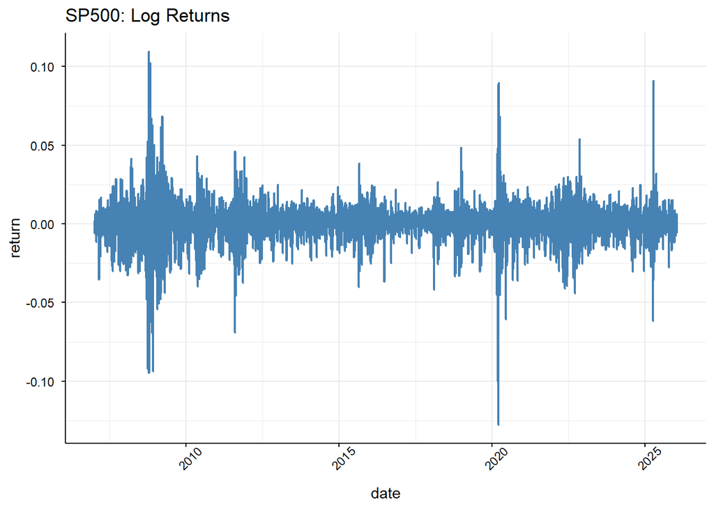

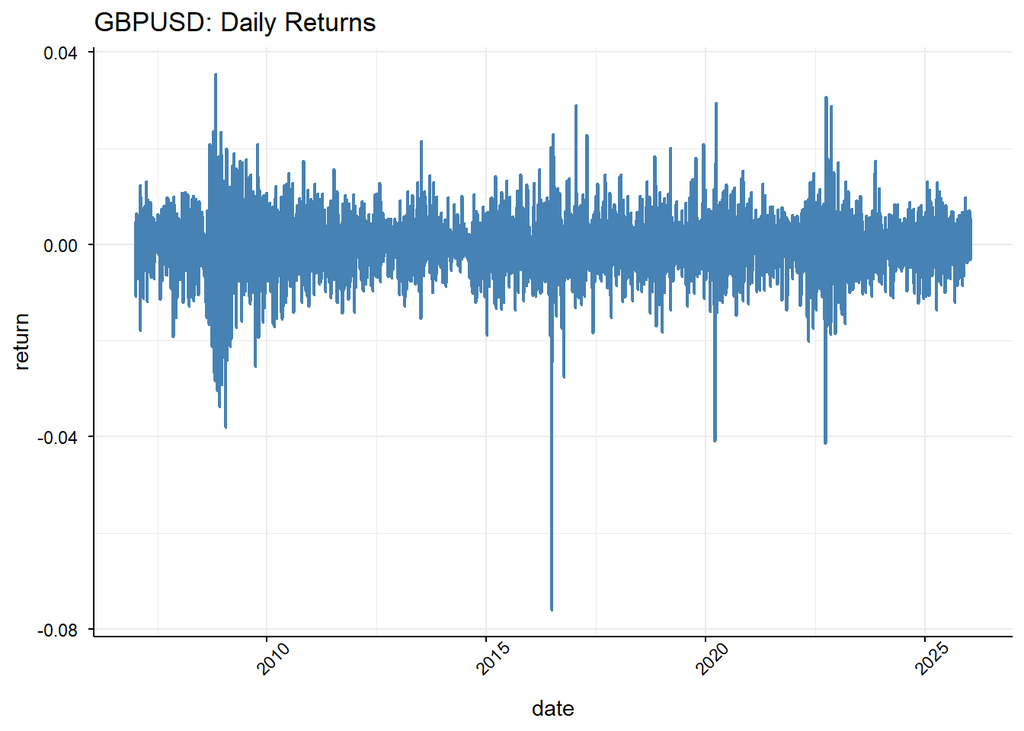

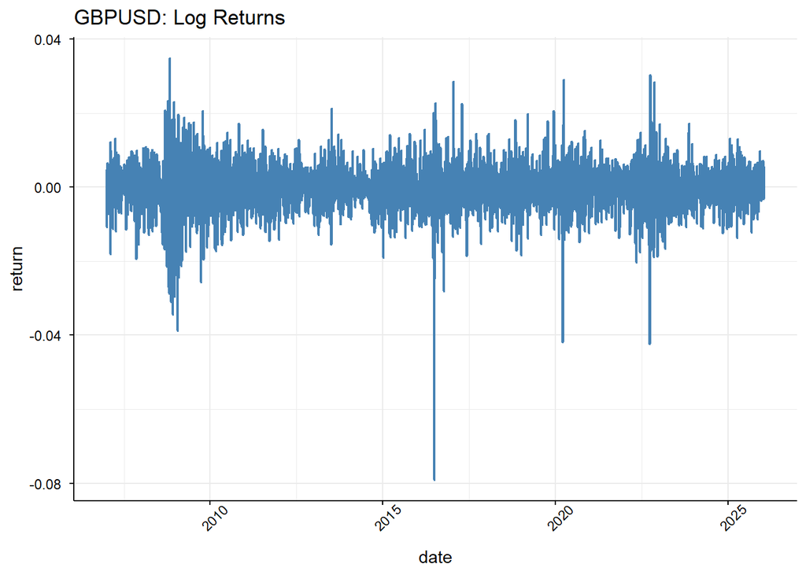

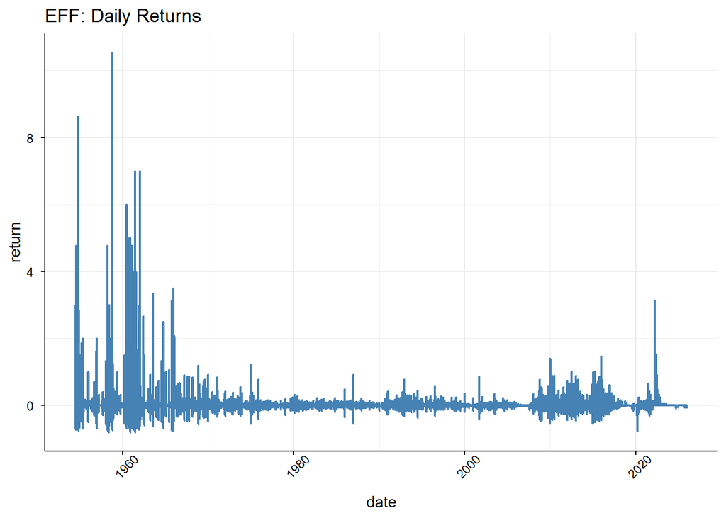

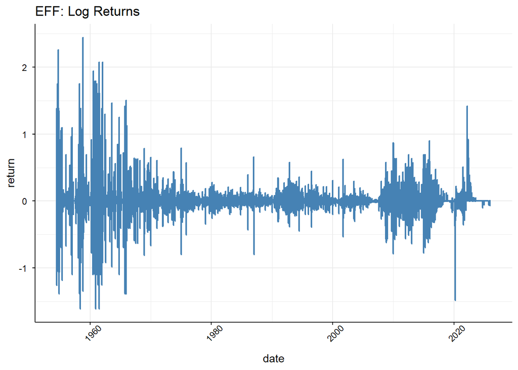

```r
for (data in data_list){

  vars <- c("dr", "lr")

  for (var in vars){

    print(
      ggplot(data = data, aes(x = date)) +
        geom_line(aes(y = !!sym(var)), colour = "steelblue", linewidth = 0.8) +
        labs(
            x = "date",
            y = "return",
            title = ifelse(
              var == "dr",
              paste0(names(data)[2],": ", "Daily Returns"),
              paste0(names(data)[2],": ", "Log Returns")
              )
            ) +
        theme_minimal() +
        # --- for further details
        theme(
          # -- options for axis text and title
          axis.text.x  = element_text(color = "black", angle = 45),
          axis.text.y  = element_text(color = "black"),
          axis.title.x = element_text(color = "black"),
          axis.title.y = element_text(color = "black"),
          # -- option to mark a line in both axis
          axis.line = element_line(color = "black"),
          # -- option to include ticks in both axis
          axis.ticks.x = element_line(color = "black"),
          axis.ticks.y = element_line(color = "black")
          )
      )
  }
}
```

## b)

Compute summary statistics like mean, median, standard deviation, skewness, kurtosis (including the robust ones) min, max, and first-order serial correlation, and report then in % per annum.

```r
tables_list <- lapply(data_list, function(data) {

  data %>%
    summarise(
      across(
        c(dr, lr),
        list(
          mean        = ~ (mean(.x, na.rm = TRUE)) * 360 * 100,   # or 252 for trading days only
          median      = ~ (median(.x, na.rm = TRUE) * 360) * 100, # or 252 for trading days only
          sd          = ~ sd(.x, na.rm = TRUE) * sqrt(360),
          skewness    = ~ skewness(.x, na.rm = TRUE),
          kurtosis    = ~ kurtosis(.x, na.rm = TRUE),
          min         = ~ (min(.x, na.rm = TRUE)) *360 * 100,
          max         = ~ (max(.x, na.rm = TRUE)) *360 * 100,
          correlation = ~ cor(.x, lag(.x), use = "complete.obs")
        ),
        .names = "{.fn}_{.col}"
      )
    ) %>%
    # --- the above operation will create a column for each statistic-return pair; with pivot-longer we separate this into two columns using the "_" separator
    pivot_longer(
      everything(),
      names_to = c("statistic", "variable"),
      names_sep = "_",
      values_to = "value"
    ) %>%
    # --- we now reconfigure the table again from the longer to the wider format
    pivot_wider(
      names_from = variable,
      values_from = value
    ) %>%
    # --- remove row indices
    column_to_rownames("statistic") %>%
    mutate(
      across(where(is.numeric), ~ round(.x, 4))
    )
})


for (i in seq_along(tables_list)){

  stargazer(
    tables_list[[i]],
    type = "text",
    summary = FALSE,
    rownames = TRUE,
    title = paste("Summary Statistics for", names(tables_list)[i]),
    digits = 4
  )
}
```

```
##
## Summary Statistics for SP500
## ===================================
##                 dr          lr
## -----------------------------------
## mean          14.7713     11.9500
## median        26.1040     26.0945
## sd            0.2372      0.2377
## skewness      -0.2067     -0.4741
## kurtosis      15.3154     15.4770
## min         -4,314.2600 -4,595.4790
## max         4,168.8130  3,944.5910
## correlation   -0.1246     -0.1225
## -----------------------------------
##
## Summary Statistics for GBPUSD
## ===================================
##                 dr          lr
## -----------------------------------
## mean          -2.0594     -2.6925
## median        -0.4622     -0.4622
## sd            0.1124      0.1126
## skewness      -0.6456     -0.7425
## kurtosis      11.8498     12.7863
## min         -2,737.3830 -2,847.0520
## max         1,276.6550  1,254.5400
## correlation   0.0218      0.0227
## -----------------------------------
##
## Summary Statistics for EFF
## =====================================
##                  dr           lr
## -------------------------------------
## mean          282.1971      1.6116
## median           0            0
## sd             3.6019       2.1346
## skewness      23.4599       2.5822
## kurtosis      867.9980     98.0182
## min           -28,800    -57,939.7600
## max         379,384.6000 88,044.6900
## correlation   -0.0706      -0.1367
## -------------------------------------
```

**Robust Measures of Skewness**

Sample Skewness

$$\hat{s} = \frac{1}{T-1} \sum_{i=1}^{T} \frac{(x_t -
\hat{\mu})^3}{\hat{\sigma}^3}$$

Bowley’s Coefficient of Skewness

$$sk_2 = \frac{Q_3 + Q_1 - 2Q_2}{Q_3 - Q_1}$$

Groeneveld & Meeden’s Coefficient of Skewness

$$sk_3 = \frac{\mu - Q_2}{E|x - Q_2|}$$

Pearson’s Coefficient of Skewness

$$sk_4 = \frac{\mu - Q_2}{\sigma}$$

**Robust Measures of Kurtosis**

Sample Kurtosis

$$\hat{k} = \frac{1}{T-1} \sum_{i=1}^{T} \frac{(x_t -
\hat{\mu})^4}{\hat{\sigma}^4}$$

Moor’s Coefficient of Kurtosis

$$ku_2 = \frac{(E_7 - E_5) + (E_3 - E_1)}{E_6 - E_2} - 1.23$$

Hogg’s Coefficient of Kurtosis

$$ku_3 = \frac{U_{0.05} - L_{0.05}}{U_{0.5}- L_{0.5}} - 2.59$$

Crom & Siddiqui’s Coefficient of Kurtosis

$$ku_4 = \frac{F^{-1}(0.975)+F^{-1}(0.025)}{F^{-1}(0.75)-F^{-1}(0.25)} -
2.91$$

```r
robust_sk_ku <- function(x){

  # --- omitting NAs
  x <- na.omit(x)

  # --- mean and centered moments
  mu <- mean(x)
  # -- 2nd centered moment: variance
  m2   <- mean((x - mu)^2)
  # -- 3rd centered moment: non-standardized skewness (i.e. sample skewness numerator)
  m3   <- mean((x - mu)^3)
  # -- 4th centered moment: non-standardized kurtosis(i.e. sample kurtosis numerator)
  m4   <- mean((x - mu)^4)

  # --- quartiles
  Q1 <- quantile(x, 0.25)
  Q2 <- quantile(x, 0.50)
  Q3 <- quantile(x, 0.75)

  # --- octiles
  E1 <- quantile(x, 1/8)
  E2 <- quantile(x, 2/8)
  E3 <- quantile(x, 3/8)
  E5 <- quantile(x, 5/8)
  E6 <- quantile(x, 6/8)
  E7 <- quantile(x, 7/8)

  # --- tail quantiles
  E975 <- quantile(x, 0.975)
  E025 <- quantile(x, 0.025)
  E750 <- quantile(x, 0.750)
  E250 <- quantile(x, 0.250)

  # --- tail means
  U05 <- mean(x[x >= quantile(x, 0.95)])
  L05 <- mean(x[x <= quantile(x, 0.05)])
  U50 <- mean(x[x >  Q2])
  L50 <- mean(x[x <= Q2])

  # --- skewness measures
  s   <- m3 / (m2^(3/2))
  sk2 <- (Q3 + Q1 - 2*Q2) / (Q3 - Q1)              # Bowley
  sk3 <- (mu - Q2) / mean(abs(x - Q2))             # Groeneveld–Meeden
  sk4 <- (mu - Q2) / sd(x)                         # Pearson

  # --- kurtosis measures
  k   <- m4 / (m2^2)
  ku2 <- ((E7 - E5 + E3 - E1) / (E6 - E2)) - 1.23  # Moors
  ku3 <- ((U05 - L05) / (U50 - L50)) - 2.59        # Hogg
  ku4 <- ((E975 - E025) / (E750 - E250)) - 2.91    # Crow–Siddiqui

  data.frame(
    statistic = c(
        "Sample skewness",
        "Bowley skewness",
        "Groeneveld–Meeden skewness",
        "Pearson skewness",
        "Sample kurtosis",
        "Moors kurtosis",
        "Hogg kurtosis",
        "Crow–Siddiqui kurtosis"
      ),
      value = c(
        s,
        sk2,
        sk3,
        sk4,
        k,
        ku2,
        ku3,
        ku4
      ),
      check.names = FALSE
    )
}
```

```r
tables_list2 <- lapply(data_list, function(data) {

  bind_rows(
    dr = robust_sk_ku(data$dr),
    lr = robust_sk_ku(data$lr),
    .id = "variable"
  ) %>%
    pivot_wider(
      names_from  = variable,
      values_from = value
    ) %>%
    column_to_rownames("statistic") %>%
    mutate(
      across(where(is.numeric), ~ round(.x, 4))
    )
})



for (i in seq_along(tables_list2)){

  stargazer(
    tables_list2[[i]],
    type = "text",
    summary = FALSE,
    rownames = TRUE,
    title = paste("Robust Measures of Skewness and Kurtosis for", names(data_list)[i]),
    digits = 4
  )
}
```

```
##
## Robust Measures of Skewness and Kurtosis for SP500
## ==========================================
##                              dr      lr
## ------------------------------------------
## Sample skewness            -0.2067 -0.4741
## Bowley skewness            0.0319  0.0294
## Groeneveld–Meeden skewness -0.0394 -0.0491
## Pearson skewness           -0.0252 -0.0314
## Sample kurtosis            15.3154 15.4770
## Moors kurtosis             0.4463  0.4476
## Hogg kurtosis              1.0991  1.1038
## Crow–Siddiqui kurtosis     1.9862  1.9976
## ------------------------------------------
##
## Robust Measures of Skewness and Kurtosis for GBPUSD
## ==========================================
##                              dr      lr
## ------------------------------------------
## Sample skewness            -0.6456 -0.7425
## Bowley skewness            0.0096  0.0081
## Groeneveld–Meeden skewness -0.0105 -0.0146
## Pearson skewness           -0.0075 -0.0104
## Sample kurtosis            11.8498 12.7863
## Moors kurtosis             0.1425  0.1426
## Hogg kurtosis              0.5624  0.5645
## Crow–Siddiqui kurtosis     0.8457  0.8466
## ------------------------------------------
##
## Robust Measures of Skewness and Kurtosis for EFF
## ===========================================
##                               dr      lr
## -------------------------------------------
## Sample skewness            23.4599  2.5822
## Bowley skewness
## Groeneveld–Meeden skewness  0.2230  0.0014
## Pearson skewness            0.0413  0.0004
## Sample kurtosis            867.9980 98.0182
## Moors kurtosis               Inf      Inf
## Hogg kurtosis               2.1223  2.5079
## Crow–Siddiqui kurtosis       Inf      Inf
## -------------------------------------------
```

## c)

Plot the histogram of each return series.

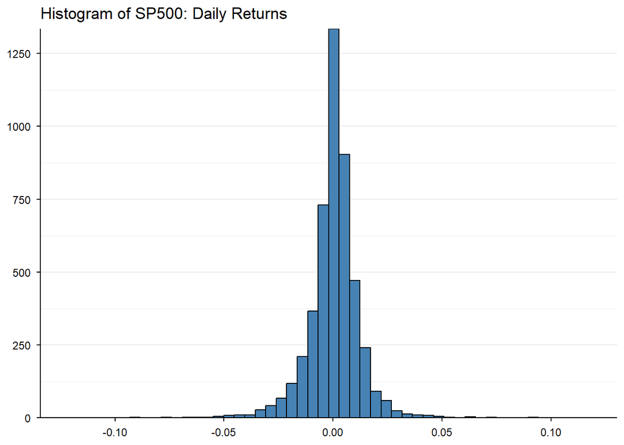

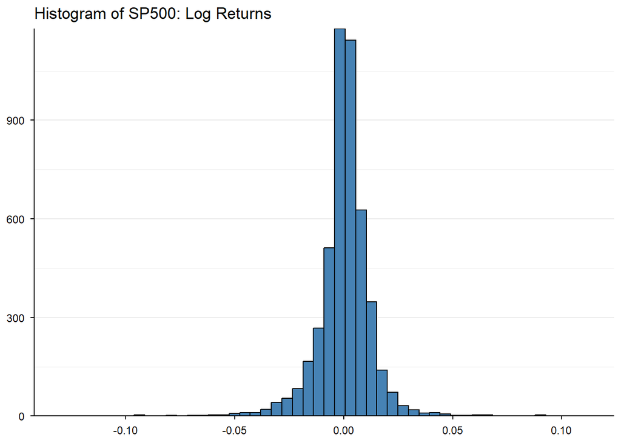

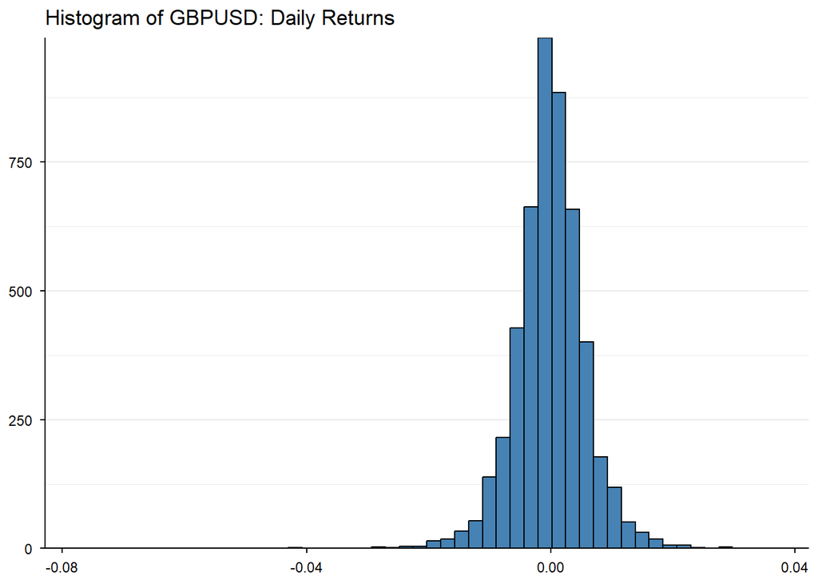

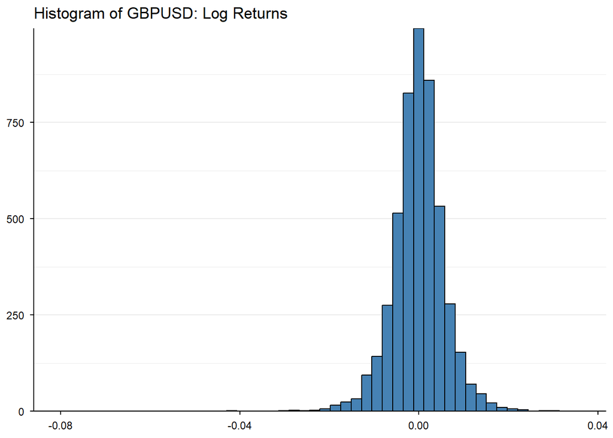

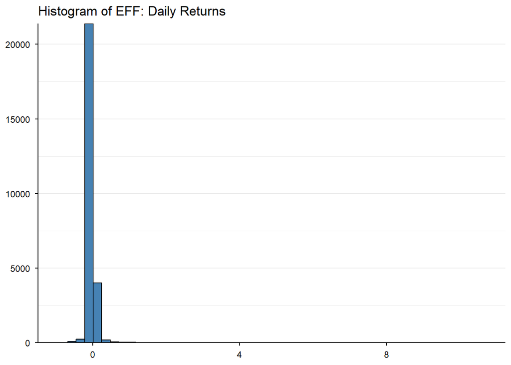

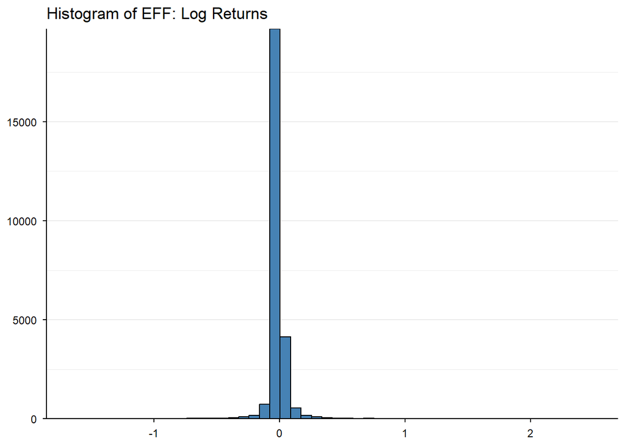

```r
for (data in data_list){

  vars <- c("dr", "lr")

  for (var in vars){

    print(
      ggplot(data = data, aes(x = !!sym(var))) +
        geom_histogram(
          bins = 50,
          color = "black",
          fill = "steelblue"
        ) +
        scale_y_continuous(
          expand = c(0,0)
        ) +
        labs(
            x = NULL,
            y = NULL,
            title = ifelse(
              var == "dr",
              paste0("Histogram of ",names(data)[2],": ", "Daily Returns"),
              paste0("Histogram of ",names(data)[2],": ", "Log Returns")
              )
            ) +
        theme_minimal() +
        # --- for further details
        theme(
          # -- options for axis text and title
          axis.text.x  = element_text(color = "black"),
          axis.text.y  = element_text(color = "black"),
          axis.title.x = element_text(color = "black"),
          axis.title.y = element_text(color = "black"),
          # -- option to mark a line in both axis
          axis.line = element_line(color = "black"),
          # -- option to include ticks in both axis
          axis.ticks.x = element_line(color = "black"),
          axis.ticks.y = element_line(color = "black"),
          # -- remove vertical grid lines
          panel.grid.major.x = element_blank(),
          panel.grid.minor.x = element_blank()
          )
      )
  }
}
```

## d)

Compute the variance-covariance matrix.

```r
data_join_dr <- usffr_d %>%
  inner_join(sp500_d, by = "date", suffix = c("","_SP500")) %>%
  inner_join(gbpusd_d, by = "date", suffix = c("","_GBPUSD")) %>%
  arrange(date) %>%
  select(contains("dr")) %>%
  rename(
    EFF    = dr,
    SP500  = dr_SP500,
    GBPUSD = dr_GBPUSD
  )

data_join_lr <- usffr_d %>%
  inner_join(sp500_d, by = "date", suffix = c("","_SP500")) %>%
  inner_join(gbpusd_d, by = "date", suffix = c("","_GBPUSD")) %>%
  arrange(date) %>%
  select(contains("lr")) %>%
  rename(
    EFF    = lr,
    SP500  = lr_SP500,
    GBPUSD = lr_GBPUSD
  )

sigma_dr <- cov(data_join_dr, use = "complete.obs")

sigma_lr <- cov(data_join_lr, use = "complete.obs")

stargazer(
  sigma_dr,
  type = "text",
  summary = FALSE,
  rownames = TRUE,
  digits = 4,
  title = "Variance–Covariance Matrix: Daily Returns"
)
```

```
##
## Variance–Covariance Matrix: Daily Returns
## ===================================
##           EFF     SP500    GBPUSD
## -----------------------------------
## EFF     0.0126   -0.00004 -0.000004
## SP500  -0.00004   0.0002   0.00001
## GBPUSD -0.000004 0.00001   0.00003
## -----------------------------------
```

```r
stargazer(
  sigma_lr,
  type = "text",
  summary = FALSE,
  rownames = TRUE,
  digits = 4,
  title = "Variance–Covariance Matrix: Log Returns"
)
```

```
##
## Variance–Covariance Matrix: Log Returns
## ===================================
##           EFF     SP500    GBPUSD
## -----------------------------------
## EFF     0.0090   -0.00001 -0.000001
## SP500  -0.00001   0.0002   0.00001
## GBPUSD -0.000001 0.00001   0.00003
## -----------------------------------
```

# Exercise 2

```r
# --- S&P500 Index
sp500_m <- sp500 %>%
  # -- safeguard to make sure our dates are in order
  arrange(date) %>%
  mutate(
    # -- define the calendar end of month (EOM) to facilitate the grouping of the data
    month_end = ceiling_date(date, "month") - days(1)
  ) %>%
  group_by(month_end) %>%
  summarise(
    # -- last observed working day
    last_trading_day = max(date),
    SP500_EOM = SP500[which.max(date)],
    .groups = "drop"
  ) %>%
  arrange(month_end) %>%
  mutate(
    # -- simple return
    sr = (SP500_EOM / lag(SP500_EOM)) - 1,
    # -- log return
    lr = log(SP500_EOM) - log(lag(SP500_EOM))
  )

# --- GBPUSD Exchange Rate
gbpusd_m <- gbpusd %>%
  arrange(date) %>%
  mutate(
    month_end = ceiling_date(date, "month") - days(1)
  ) %>%
  group_by(month_end) %>%
  summarise(
    last_trading_day = max(date),
    GBPUSD_EOM = GBPUSD[which.max(date)],
    .groups = "drop"
  ) %>%
  arrange(month_end) %>%
  mutate(
    sr = (GBPUSD_EOM / lag(GBPUSD_EOM)) - 1,
    lr = log(GBPUSD_EOM) - log(lag(GBPUSD_EOM))
  )

# --- US Federal Fund Rate
usffr_m <- usffr %>%
  arrange(date) %>%
  mutate(
    month_end = ceiling_date(date, "month") - days(1)
  ) %>%
  group_by(month_end) %>%
  summarise(
    last_trading_day = max(date),
    EFF_EOM = EFF[which.max(date)],
    .groups = "drop"
  ) %>%
  arrange(month_end) %>%
  mutate(
    sr = (EFF_EOM / lag(EFF_EOM)) - 1,
    lr = log(EFF_EOM) - log(lag(EFF_EOM))
  )
```

```r
# --- storing all these individual datasets in a single list
data_list_m <- list(
  SP500 = sp500_m,
  GBPUSD = gbpusd_m,
  EFF = usffr_m
  )
```

## a)

Plot simple returns.

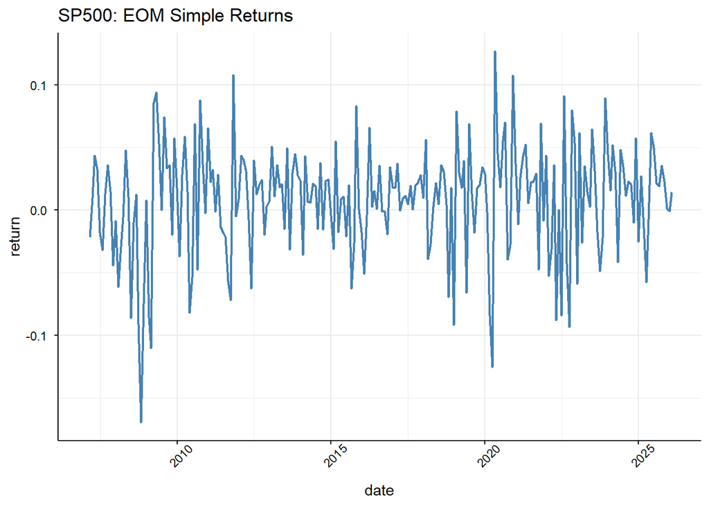

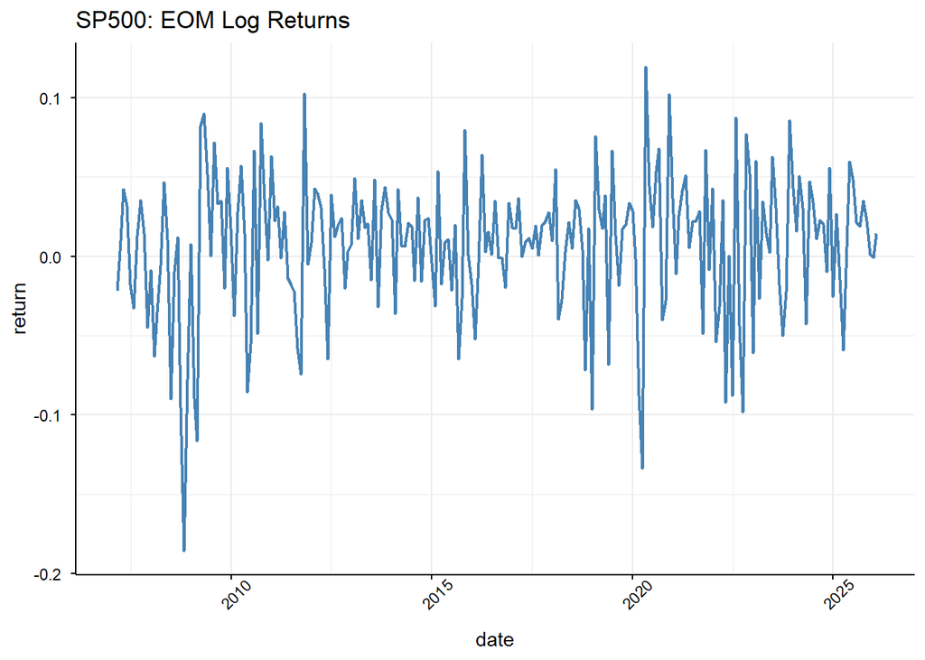

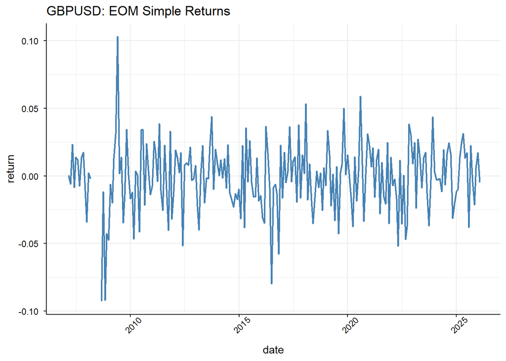

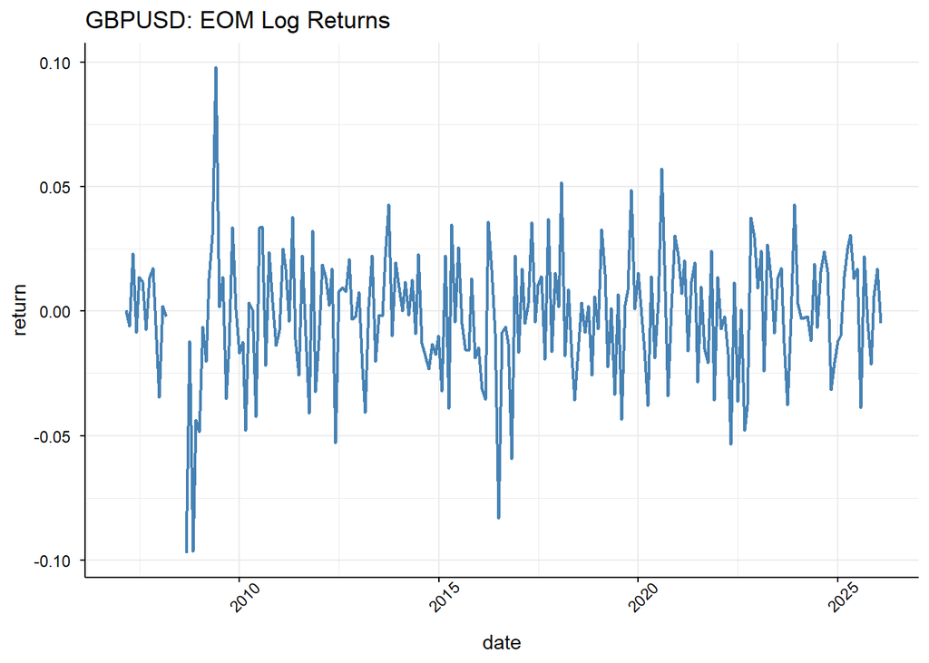

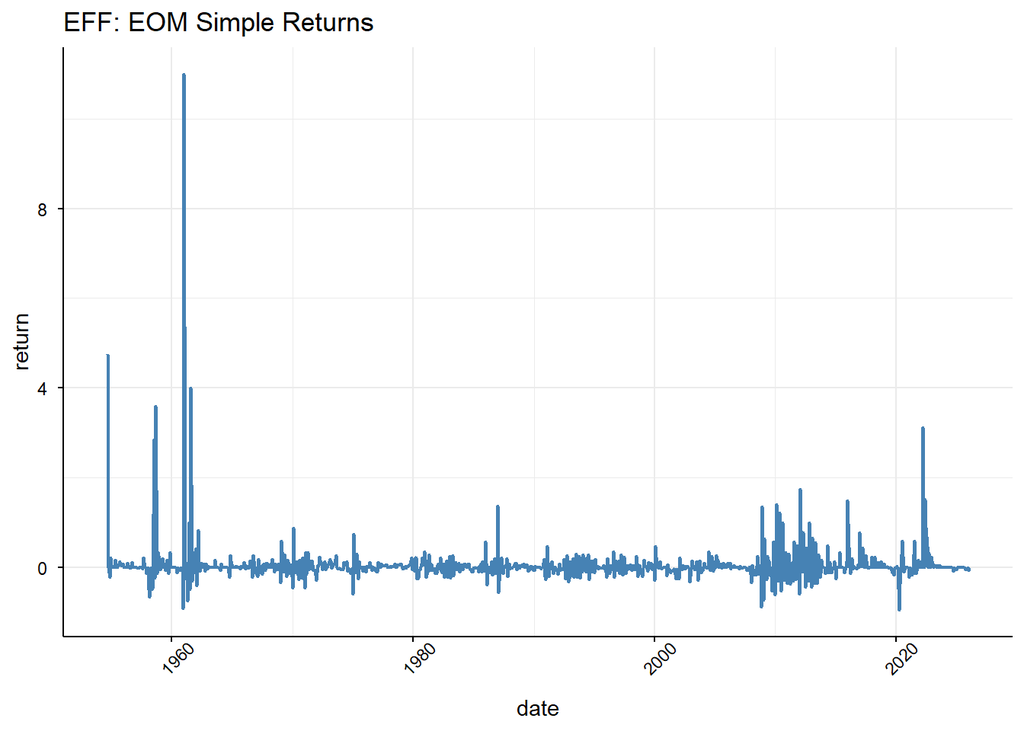

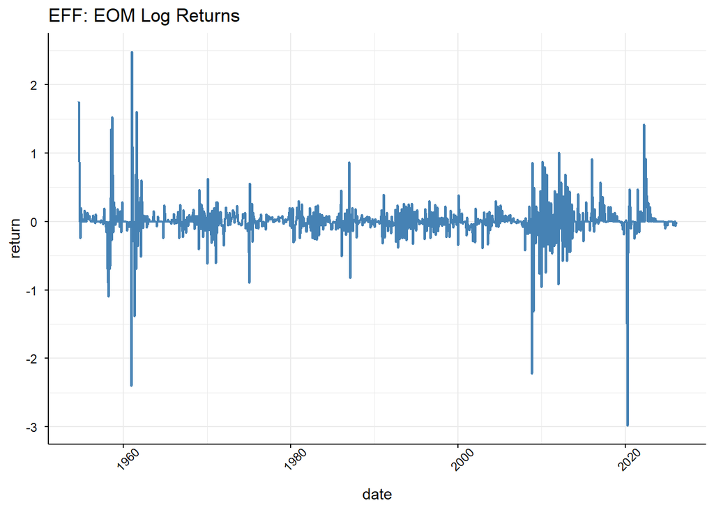

```r
for (data in data_list_m){

  vars <- c("sr", "lr")

  for (var in vars){

    print(
      ggplot(data = data, aes(x = month_end)) +
        geom_line(aes(y = !!sym(var)), colour = "steelblue", linewidth = 0.8) +
        labs(
            x = "date",
            y = "return",
            title = ifelse(
              var == "sr",
              paste0(sub("_.*$","",names(data)[3]),": ", "EOM Simple Returns"),
              paste0(sub("_.*$","",names(data)[3]),": ", "EOM Log Returns")
              )
            ) +
        theme_minimal() +
        # --- for further details
        theme(
          # -- options for axis text and title
          axis.text.x  = element_text(color = "black", angle = 45),
          axis.text.y  = element_text(color = "black"),
          axis.title.x = element_text(color = "black"),
          axis.title.y = element_text(color = "black"),
          # -- option to mark a line in both axis
          axis.line = element_line(color = "black"),
          # -- option to include ticks in both axis
          axis.ticks.x = element_line(color = "black"),
          axis.ticks.y = element_line(color = "black")
          )
      )
  }
}
```

## b)

Compute summary statistics like mean, median, standard deviation, skewness, kurtosis (including the robust ones) min, max, and first-order serial correlation, and report then in % per annum.

```r
tables_list_m <- lapply(data_list_m, function(data) {

  data %>%
    summarise(
      across(
        c(sr, lr),
        list(
          mean        = ~ mean(.x, na.rm = TRUE) * 12 * 100,
          median      = ~ median(.x, na.rm = TRUE) * 12 * 100,
          sd          = ~ sd(.x, na.rm = TRUE) * sqrt(12),
          skewness    = ~ skewness(.x, na.rm = TRUE),
          kurtosis    = ~ kurtosis(.x, na.rm = TRUE),
          min         = ~ (min(.x, na.rm = TRUE)) * 12 * 100,
          max         = ~ (max(.x, na.rm = TRUE)) * 12 * 100,
          correlation = ~ cor(.x, lag(.x), use = "complete.obs")
        ),
        .names = "{.fn}_{.col}"
      )
    ) %>%
    # --- the above operation will create a column for each statistic-return pair; with pivot-longer we separate this into two columns using the "_" separator
    pivot_longer(
      everything(),
      names_to = c("statistic", "variable"),
      names_sep = "_",
      values_to = "value"
    ) %>%
    # --- we now reconfigure the table again from the longer to the wider format
    pivot_wider(
      names_from = variable,
      values_from = value
    ) %>%
    # --- remove row indices
    column_to_rownames("statistic") %>%
    mutate(
      across(where(is.numeric), ~ round(.x, 4))
    )
})

lapply(seq_along(tables_list_m), function(i) {
  kable(
    tables_list_m[[i]],
    caption = paste("Summary Statistics for", names(tables_list_m)[i]),
    digits = 4
  )
})
```

```
## [[1]]
##
##
## Table: Summary Statistics for SP500
##
## |            |        sr|        lr|
## |:-----------|---------:|---------:|
## |mean        |    9.5173|    8.2870|
## |median      |   17.4600|   17.3342|
## |sd          |    0.1544|    0.1557|
## |skewness    |   -0.5984|   -0.7829|
## |kurtosis    |    4.0209|    4.4257|
## |min         | -203.3094| -222.7638|
## |max         |  152.2128|  143.3050|
## |correlation |    0.0173|    0.0314|
##
## [[2]]
##
##
## Table: Summary Statistics for GBPUSD
##
## |            |        sr|        lr|
## |:-----------|---------:|---------:|
## |mean        |   -1.6308|   -2.0216|
## |median      |   -1.8400|   -1.8414|
## |sd          |    0.0881|    0.0886|
## |skewness    |   -0.2367|   -0.3774|
## |kurtosis    |    4.7568|    4.8070|
## |min         | -111.2190| -116.7154|
## |max         |  123.6295|  117.6673|
## |correlation |    0.0354|    0.0363|
##
## [[3]]
##
##
## Table: Summary Statistics for EFF
##
## |            |         sr|         lr|
## |:-----------|----------:|----------:|
## |mean        |    64.0041|     3.7458|
## |median      |     0.0000|     0.0000|
## |sd          |     1.8146|     1.0288|
## |skewness    |    12.9248|    -1.0257|
## |kurtosis    |   239.5759|    33.6990|
## |min         | -1139.2405| -3579.7842|
## |max         | 13200.0000|  2981.8880|
## |correlation |    -0.1419|    -0.2815|
```

**Robust Measures of Skewness & Kurtosis**

```r
tables_list2_m <- lapply(data_list_m, function(data) {

  bind_rows(
    dr = robust_sk_ku(data$sr),
    lr = robust_sk_ku(data$lr),
    .id = "variable"
  ) %>%
    pivot_wider(
      names_from  = variable,
      values_from = value
    ) %>%
    column_to_rownames("statistic") %>%
    mutate(
      across(where(is.numeric), ~ round(.x, 4))
    )
})

lapply(seq_along(tables_list2_m), function(i) {
  kable(
    tables_list2_m[[i]],
    caption = paste("Robust Measures of Skewness and Kurtosis for", names(tables_list_m)[i]),
    digits = 4
  )
})
```

```
## [[1]]
##
##
## Table: Robust Measures of Skewness and Kurtosis for SP500
##
## |                           |      dr|      lr|
## |:--------------------------|-------:|-------:|
## |Sample skewness            | -0.5984| -0.7829|
## |Bowley skewness            | -0.2108| -0.2232|
## |Groeneveld–Meeden skewness | -0.1988| -0.2267|
## |Pearson skewness           | -0.1485| -0.1678|
## |Sample kurtosis            |  4.0209|  4.4257|
## |Moors kurtosis             |  0.1814|  0.1914|
## |Hogg kurtosis              |  0.2817|  0.3090|
## |Crow–Siddiqui kurtosis     |  0.4399|  0.4795|
##
## [[2]]
##
##
## Table: Robust Measures of Skewness and Kurtosis for GBPUSD
##
## |                           |      dr|      lr|
## |:--------------------------|-------:|-------:|
## |Sample skewness            | -0.2367| -0.3774|
## |Bowley skewness            |  0.0821|  0.0743|
## |Groeneveld–Meeden skewness |  0.0090| -0.0077|
## |Pearson skewness           |  0.0069| -0.0059|
## |Sample kurtosis            |  4.7568|  4.8070|
## |Moors kurtosis             |  0.0172|  0.0238|
## |Hogg kurtosis              |  0.1249|  0.1340|
## |Crow–Siddiqui kurtosis     | -0.0502| -0.0369|
##
## [[3]]
##
##
## Table: Robust Measures of Skewness and Kurtosis for EFF
##
## |                           |       dr|      lr|
## |:--------------------------|--------:|-------:|
## |Sample skewness            |  12.9248| -1.0257|
## |Bowley skewness            |   0.0895|  0.0603|
## |Groeneveld–Meeden skewness |   0.3371|  0.0225|
## |Pearson skewness           |   0.1018|  0.0105|
## |Sample kurtosis            | 239.5759| 33.6990|
## |Moors kurtosis             |   1.2026|  1.1762|
## |Hogg kurtosis              |   2.7340|  2.4203|
## |Crow–Siddiqui kurtosis     |   6.4329|  5.8649|
```

## c)

Plot the histogram of each return series.

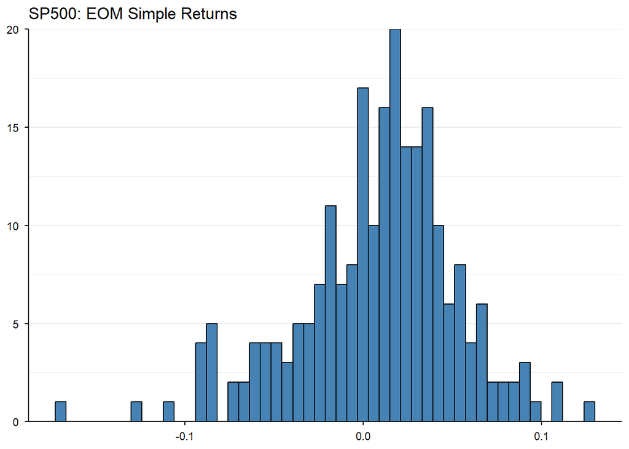

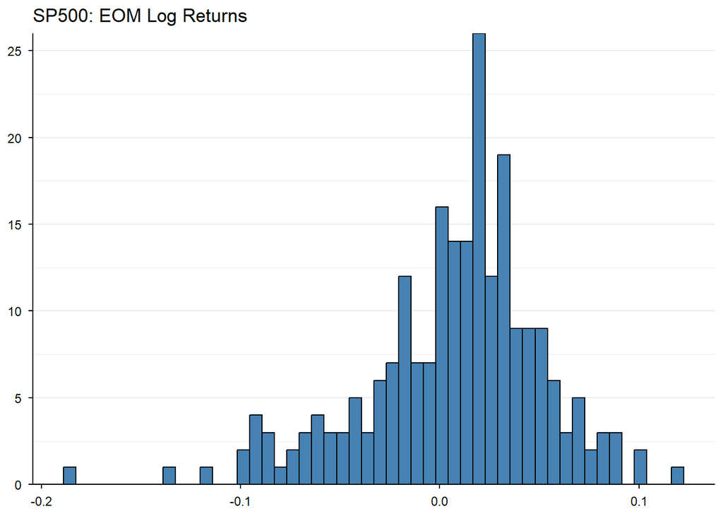

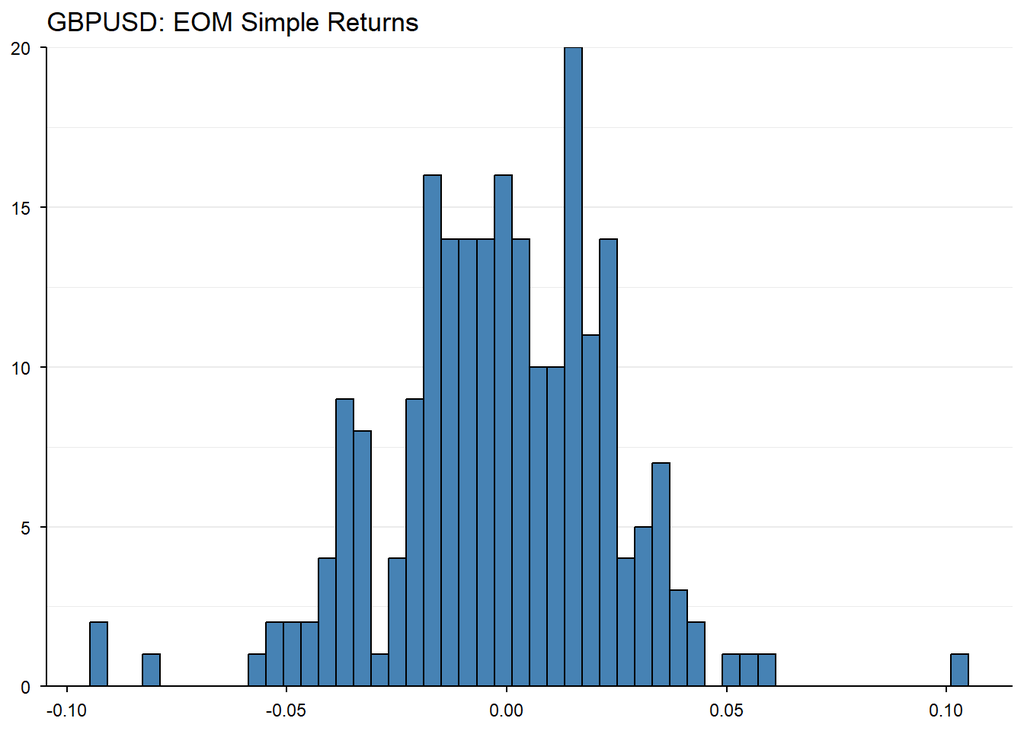

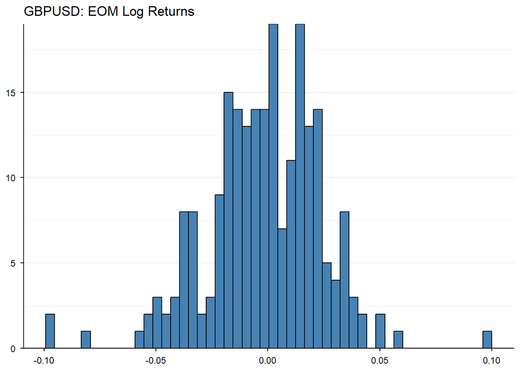

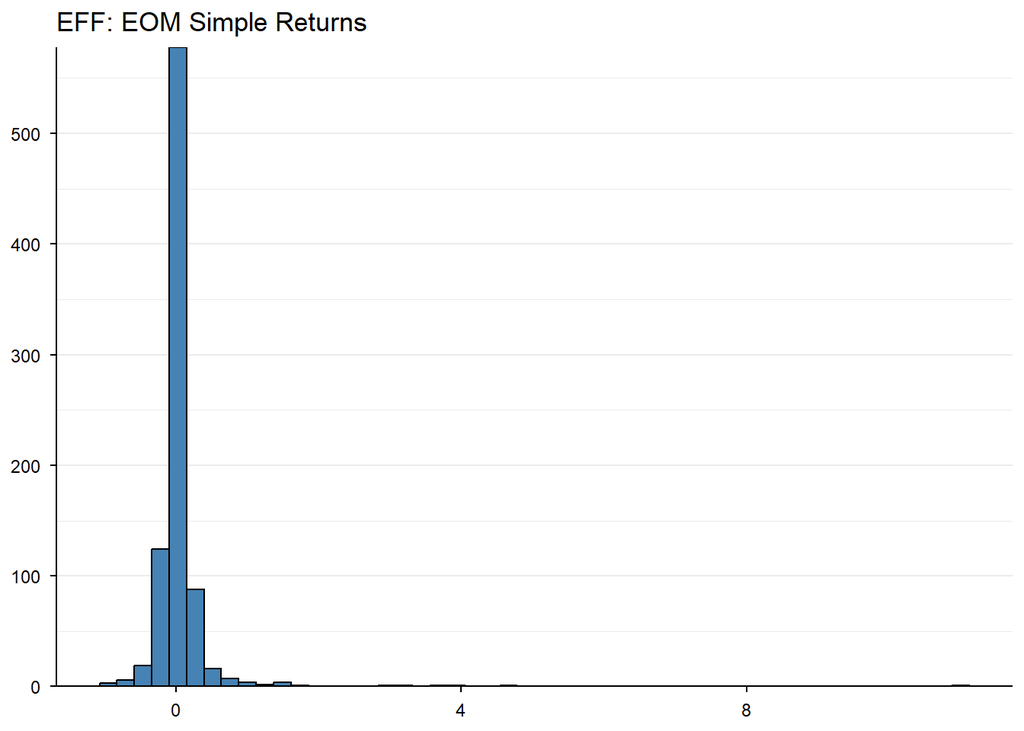

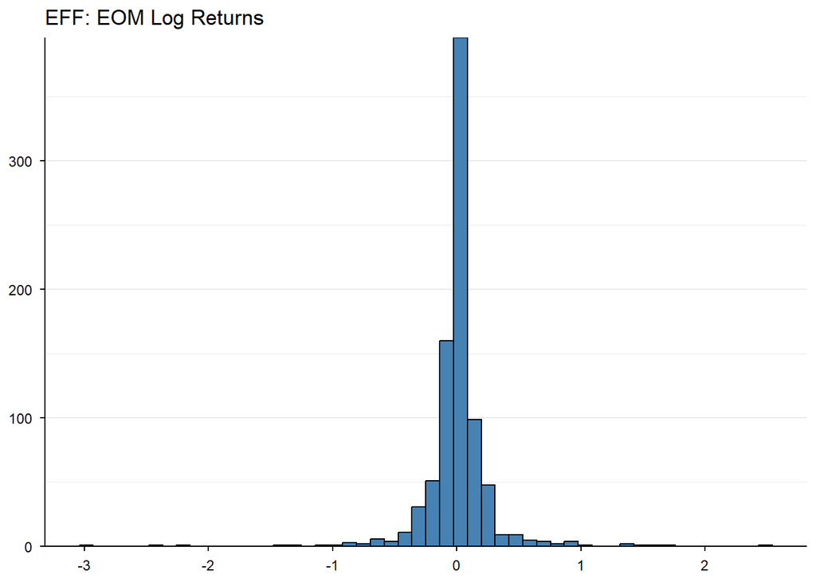

```r
for (data in data_list_m){

  vars <- c("sr", "lr")

  for (var in vars){

    print(
      ggplot(data = data, aes(x = !!sym(var))) +
        geom_histogram(
          bins = 50,
          color = "black",
          fill = "steelblue"
        ) +
        scale_y_continuous(
          expand = c(0,0)
        ) +
        labs(
            x = NULL,
            y = NULL,
            title = ifelse(
              var == "sr",
              paste0(sub("_.*$","",names(data)[3]),": ", "EOM Simple Returns"),
              paste0(sub("_.*$","",names(data)[3]),": ", "EOM Log Returns")
              )
            ) +
        theme_minimal() +
        # --- for further details
        theme(
          # -- options for axis text and title
          axis.text.x  = element_text(color = "black"),
          axis.text.y  = element_text(color = "black"),
          axis.title.x = element_text(color = "black"),
          axis.title.y = element_text(color = "black"),
          # -- option to mark a line in both axis
          axis.line = element_line(color = "black"),
          # -- option to include ticks in both axis
          axis.ticks.x = element_line(color = "black"),
          axis.ticks.y = element_line(color = "black"),
          # -- remove vertical grid lines
          panel.grid.major.x = element_blank(),
          panel.grid.minor.x = element_blank()
          )
      )
  }
}
```